# Project Business Statistics: E-news Express

**Marks: 60**

## Define Problem Statement and Objectives

**An online news portal called E-news Express aims to expand its business by acquiring new subscribers. Every user who visits the website takes specific actions based on their interest and the company (E-news Express) plans to analyze these actions to understand user interest and determine how to better engage the users of the site.**

**The executives at E-news Express are of the opinion that there has been a decline in new monthly subscribers compared to the past year because the current webpage is not defined well enough in terms of outline and recommended content to keep customers enaged long enough to make a decison to subscribe.**

### Objective

**Based on the criticism from the executives, the design team embarked on a research and created a new landing page that has a new outine and relevant content shown compared to the old landing page.**

**To test the effectiveness of the new landing page in gathering new subscribers, an experiment was conducted by selecting 100 users randomly and dividing them into two equal groups. The first group called the control grooup was served with the existing landing page and the second group called the treatment group was served with the new landing page and data was collected from both groups based on their interactions with the two versions of the landing page.**

**As a Data Scientist at E-news express, I have been asked to explore the data and perform statistical analysis (at a significance level of 5%) to determine the effectiveness of the new landing page in gathering new subscribers for the news portal by answering the questions below.**

**1. Do the users spend more time on the new landing page than on the existing landing page?**

**2. Is the conversion rate (the proportion of users who visit the landing page and get converted) for the new page greater than the conversion rate for the old page?**

**3. Does the converted status depend on the preferred language?**

**4. Is the time spent on the new page the same for the different language users?**

### Data Dictionary

**1.user_id - Unique user ID of the person visiting the website.**

**2.group - Whether the user belongs to the first group (control) or the second group (treatment).**

**3.landing_page - Whether the landing page is new or old.**

**4.time_spent_on_the_page - Time (in minutes) spent by the user on the landing page.**

**5.converted - Whether the user gets converted to a subscriber of the news portal or not.**

**6.language_preferred - Language chosen by the user to view the landing page.**

## Import all the necessary libraries

```python
#import the important packages
import pandas as pd #library used for data manipulation and analysis
import numpy as np # library used for working with arrays.
import matplotlib.pyplot as plt # library for plots and visualisations
import seaborn as sns # library for visualisations
%matplotlib inline

import scipy.stats as stats # this library contains a large number of probability distributions as well as a growing library of statistical functions.
```

## Reading the Data into a DataFrame

```python
df=pd.read_csv('abtest.csv')
```

## Explore the dataset and extract insights using Exploratory Data Analysis

- Data Overview
  - Viewing the first and last few rows of the dataset
  - Checking the shape of the dataset
  - Getting the statistical summary for the variables
- Check for missing values
- Check for duplicates

```python
df.head()#To get information on the first five rows of the data set
```

|  | user_id | group | landing_page | time_spent_on_the_page | converted | language_preferred |
| --- | --- | --- | --- | --- | --- | --- |
| 0 | 546592 | control | old | 3.48 | no | Spanish |
| 1 | 546468 | treatment | new | 7.13 | yes | English |
| 2 | 546462 | treatment | new | 4.40 | no | Spanish |
| 3 | 546567 | control | old | 3.02 | no | French |
| 4 | 546459 | treatment | new | 4.75 | yes | Spanish |

```python
df.tail()#To get information on the last five rows of the data set
```

|  | user_id | group | landing_page | time_spent_on_the_page | converted | language_preferred |
| --- | --- | --- | --- | --- | --- | --- |
| 95 | 546446 | treatment | new | 5.15 | no | Spanish |
| 96 | 546544 | control | old | 6.52 | yes | English |
| 97 | 546472 | treatment | new | 7.07 | yes | Spanish |
| 98 | 546481 | treatment | new | 6.20 | yes | Spanish |
| 99 | 546483 | treatment | new | 5.86 | yes | English |

```python
df.shape
```

```
(100, 6)
```

**There are 100 rows and 6 columns in the data set**

```python
df.info()
```

```
<class 'pandas.core.frame.DataFrame'>
RangeIndex: 100 entries, 0 to 99
Data columns (total 6 columns):
 #   Column                  Non-Null Count  Dtype
---  ------                  --------------  -----
 0   user_id                 100 non-null    int64
 1   group                   100 non-null    object
 2   landing_page            100 non-null    object
 3   time_spent_on_the_page  100 non-null    float64
 4   converted               100 non-null    object
 5   language_preferred      100 non-null    object
dtypes: float64(1), int64(1), object(4)
memory usage: 4.8+ KB
```

**The data was stored with a memory usage of about 4.8+ kilobyte, all the data sets are stored appropriately**

**4 data sets were stored as objects, 1 as a float and the last one as an integer**

```python
df.isnull().sum()
```

```
user_id                   0
group                     0
landing_page              0
time_spent_on_the_page    0
converted                 0
language_preferred        0
dtype: int64
```

**There are no null values in the data set**

```python
df.duplicated()
```

```
0     False
1     False
2     False
3     False
4     False
      ...
95    False
96    False
97    False
98    False
99    False
Length: 100, dtype: bool
```

**There are no duplicate values in the data set**

```python
df.duplicated().sum()
```

```
0
```

**This further confirms the previous line of code that there are no duplicate values in the data set**

```python
df.describe().T #descriptive statistical summary of the numerical variables#
```

|  | count | mean | std | min | 25% | 50% | 75% | max |
| --- | --- | --- | --- | --- | --- | --- | --- | --- |
| user_id | 100.0 | 546517.0000 | 52.295779 | 546443.00 | 546467.75 | 546492.500 | 546567.2500 | 546592.00 |
| time_spent_on_the_page | 100.0 | 5.3778 | 2.378166 | 0.19 | 3.88 | 5.415 | 7.0225 | 10.71 |

**Based on the above statistic, the time spent on the page ranges from 0.19 minutes to 10.71 minutes**

**The average time spent by users on the page is about 5.37 minutes which is close to the median of 5.415 suggestive of an almost perfectly normal distribution**

```python
df.describe(include='all').T
```

|  | count | unique | top | freq | mean | std | min | 25% | 50% | 75% | max |
| --- | --- | --- | --- | --- | --- | --- | --- | --- | --- | --- | --- |
| user_id | 100.0 | NaN | NaN | NaN | 546517.0 | 52.295779 | 546443.0 | 546467.75 | 546492.5 | 546567.25 | 546592.0 |
| group | 100 | 2 | control | 50 | NaN | NaN | NaN | NaN | NaN | NaN | NaN |
| landing_page | 100 | 2 | old | 50 | NaN | NaN | NaN | NaN | NaN | NaN | NaN |
| time_spent_on_the_page | 100.0 | NaN | NaN | NaN | 5.3778 | 2.378166 | 0.19 | 3.88 | 5.415 | 7.0225 | 10.71 |
| converted | 100 | 2 | yes | 54 | NaN | NaN | NaN | NaN | NaN | NaN | NaN |
| language_preferred | 100 | 3 | Spanish | 34 | NaN | NaN | NaN | NaN | NaN | NaN | NaN |

**The website was viewed in spanish a record of 34 times more than any other language according to the descriptive statistics but further analysis shows that french was also used to view the website 34 times**

**About 54 person who visited the website were converted to subscribers after visiting the website**

### Group

```python
df['group'].value_counts()
```

```
control      50
treatment    50
Name: group, dtype: int64
```

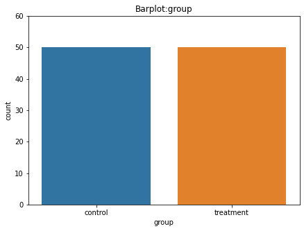

```python
plt.figure(figsize = (7,5))# figure to be drawn with a width of 7inches and an height of 5inches
plt.title('Barplot:group') #title of the plot
plt.ylim(0,60) #limit on the y-axis running from 0 to 60
sns.countplot(data = df, x = 'group');
plt.xlabel('group') #x-axis title
plt.show()
```

### observation

**Based on the results from the code above, two different groups exist which are the control and the treatment group and they are evenly distributed with a sample size of 50 each as seen from the value counts and the barplot/countplot.**

### landing_page

```python
df['landing_page'].value_counts()
```

```
old    50
new    50
Name: landing_page, dtype: int64
```

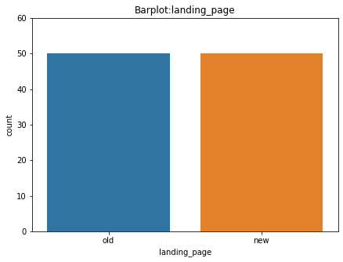

```python
plt.figure(figsize = (7,5))# figure to be drawn with a width of 7inches and an height of 5inches
plt.title('Barplot:landing_page') #title of the plot
plt.ylim(0,60) #limit on the y-axis running from 0 to 60
sns.countplot(data = df, x = 'landing_page');
plt.xlabel('landing_page') #x-axis title
plt.show()
```

### observation

**Based on the results from the code above, two different groups were split and an A/B experiment carried out by subjecting half of the sample size (50) to the new landing page while the other half were on the old landing page.**

### time_spent_on_the_page

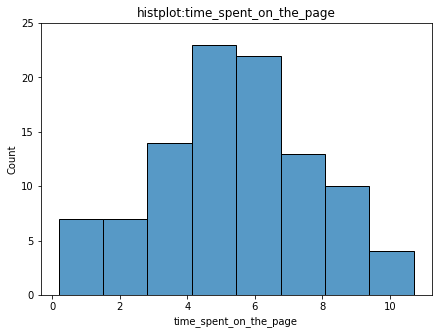

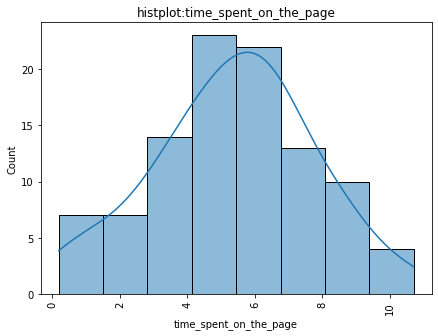

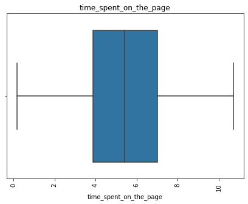

```python
plt.figure(figsize = (7,5))# figure to be drawn with a width of 7inches and an height of 5inches
plt.title('histplot:time_spent_on_the_page') #title of the plot
plt.ylim(0,25) #limit on the y-axis running from 0 to 25
sns.histplot(data = df, x = 'time_spent_on_the_page');
plt.xlabel('time_spent_on_the_page') #x-axis title
plt.show()


plt.figure(figsize = (7,5))# figure to be drawn with a width of 7inches and an height of 5inches
plt.title('histplot:time_spent_on_the_page') #title of the plot
sns.histplot(data = df, x = 'time_spent_on_the_page', kde=True);
plt.xlabel('time_spent_on_the_page') #x-axis title
plt.xticks(rotation=90); #rotating the x-labels by 90 degrees for better orientation


plt.figure(figsize = (7,5))# figure to be drawn with a width of 7inches and an height of 5inches
plt.title('time_spent_on_the_page') #title of the plot
sns.boxplot(data = df, x = 'time_spent_on_the_page');
plt.xlabel('time_spent_on_the_page') #x-axis title
plt.xticks(rotation=90); #rotating the x-labels by 90 degrees for better orientation
plt.show()
```

### observation

**The time spent on the page follows an approximately normal distribution as seen from the histogram and the density curve or kernel density estimate**

**75% of the time spent on the page was about 7 minutes**

**There are no outliers meaning nobody spent excessively long time on the page and te boxplot shows an approximate normal distribution**

### converted

```python
df['converted'].value_counts()
```

```
yes    54
no     46
Name: converted, dtype: int64
```

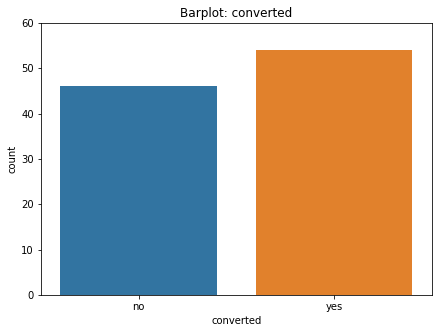

```python
plt.figure(figsize = (7,5))# figure to be drawn with a width of 7inches and an height of 5inches
plt.title('Barplot: converted') #title of the plot
plt.ylim(0,60) #limit on the y-axis running from 0 to 60
sns.countplot(data = df, x = 'converted');
plt.xlabel('converted') #x-axis title
plt.show()
```

### observation

**The results above show that about 54 people got converted to subscribers upon viewing the website and 46 were not converted**

### language_preferred

```python
df['language_preferred'].value_counts()
```

```
Spanish    34
French     34
English    32
Name: language_preferred, dtype: int64
```

[figure not shown]

```python
plt.figure(figsize = (7,5))# figure to be drawn with a width of 7inches and an height of 5inches
plt.title('Barplot: converted') #title of the plot
plt.ylim(0,35) #limit on the y-axis running from 0 to 35
sns.countplot(data = df, x ='language_preferred');
plt.xlabel('converted') #x-axis title
plt.show()
```

### observation

**34 persons viewed the website in french, another 34 persons viewed the website in spanish while 32 persons viewed the website in english**

### Bivariate Analysis

#### landing_page vs time_spent_on_the_page

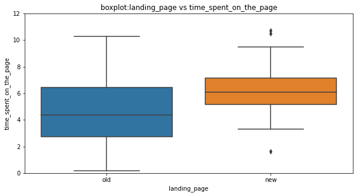

```python
plt.figure(figsize=(10,5)) # figure to be drawn with a width of 10inches and an height of 5inches
plt.title('boxplot:landing_page vs time_spent_on_the_page') #title of the plot
plt.ylim(0,12) #limit on the y-axis running from 0 to 12
sns.boxplot(x = "landing_page", y = "time_spent_on_the_page", data = df);
plt.show()
```

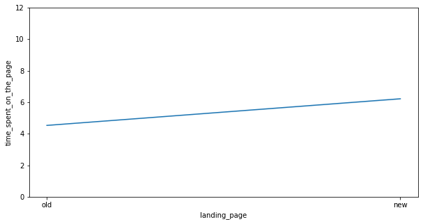

```python
plt.figure(figsize=(10,5)) # figure to be drawn with a width of 10inches and an height of 5inches
plt.ylim(0,12) #limit on the y-axis running from 0 to 12
sns.lineplot(x = "landing_page", y = "time_spent_on_the_page", data = df, ci=False);
plt.show()
```

### Observation

**The median time for viewing the new page is about 6minutes while the median time it took for viewing the old page was about 4 minutes. while it might be suggestive that the new page is having an impact on the subscribers because they are spending more time on the new page, it is not conclusive until we do our statistical tests**

**There exist outliers when looking at time it took to view the new page, if the median time was about two minutes greater than the median time for viewing the old page, one might think the smaller outliers could be attributed to internet connection problems that made the page time out. sismilarly the outliers that exceeded the maximum time for viewing the new page at 9+ minutes could be attributed to new features that could have captivated the user or maybe the user found it difficult to navigate through the page. These observations are inconclusive until we run statistical tests**

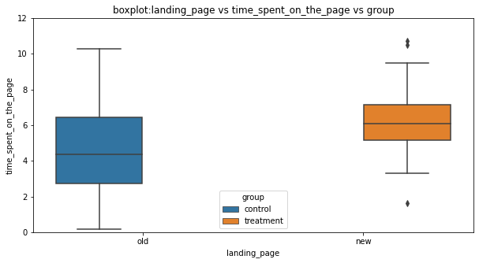

```python
plt.figure(figsize=(10,5)) # figure to be drawn with a width of 10inches and an height of 5inches
plt.title('boxplot:landing_page vs time_spent_on_the_page vs group') #title of the plot
plt.ylim(0,12) #limit on the y-axis running from 0 to 12
sns.boxplot(x = "landing_page", y = "time_spent_on_the_page", data = df, hue='group');
plt.show()
```

### Observation

**The median time spent on the landing page for individuals in the treatment group is more than the median time spent by individuals in the control group.**

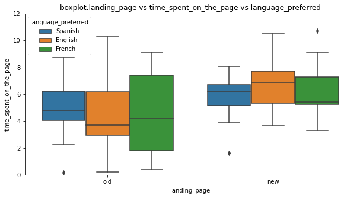

```python
plt.figure(figsize=(10,5)) # figure to be drawn with a width of 10inches and an height of 5inches
plt.title('boxplot:landing_page vs time_spent_on_the_page vs language_preferred') #title of the plot
plt.ylim(0,12) #limit on the y-axis running from 0 to 12
sns.boxplot(x = "landing_page", y = "time_spent_on_the_page", data = df, hue='language_preferred');
plt.show()
```

### Observation

**For the new landing page, the median time spent on page was highest for those who viewed the page in english and least for those who viewed the page in french**

**The median time spent on the old landing page was highest for individuals who viewed the page in spanish**

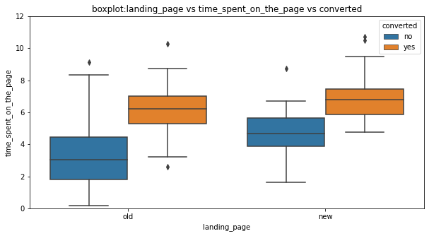

```python
plt.figure(figsize=(10,5)) # figure to be drawn with a width of 10inches and an height of 5inches
plt.title('boxplot:landing_page vs time_spent_on_the_page vs converted') #title of the plot
plt.ylim(0,12) #limit on the y-axis running from 0 to 12
sns.boxplot(x = "landing_page", y = "time_spent_on_the_page", data = df, hue='converted');
plt.show()
```

### Observation

**For both the old and new landing pages, the median time spent on the page was higher for those that were converted in comparison to those that were not converted.**

#### Converted vs time_spent_on_the_page

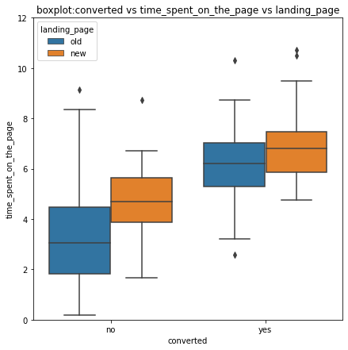

```python
plt.figure(figsize=(7,7)) # figure to be drawn with a width of 7inches and an height of 7inches
plt.title('boxplot:converted vs time_spent_on_the_page vs landing_page') #title of the plot
plt.ylim(0,12) #limit on the y-axis running from 0 to 12
sns.boxplot(data = df, x = 'converted', y='time_spent_on_the_page', hue='landing_page')
plt.show()
```

### Observation

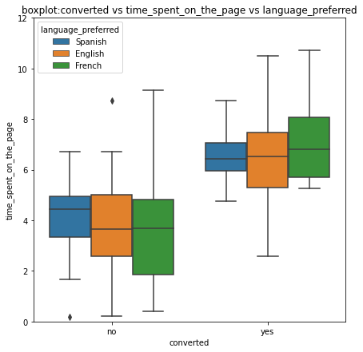

```python
plt.figure(figsize=(7,7)) # figure to be drawn with a width of 7inches and an height of 7inches
plt.title('boxplot:converted vs time_spent_on_the_page vs language_preferred') #title of the plot
plt.ylim(0,12) #limit on the y-axis running from 0 to 12
sns.boxplot(data = df, x = 'converted', y='time_spent_on_the_page', hue='language_preferred')
plt.show()
```

### observation

**The median time spent by individuals who visited the site in french was the highest for the number of people who were converted while the median time for the individuals who visited the site in spanish was highest for those that were not converted.**

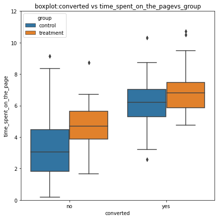

```python
plt.figure(figsize=(7,7)) # figure to be drawn with a width of 7inches and an height of 7inches
plt.title('boxplot:converted vs time_spent_on_the_pagevs_group') #title of the plot
plt.ylim(0,12) #limit on the y-axis running from 0 to 12
sns.boxplot(data = df, x = 'converted', y='time_spent_on_the_page', hue='group')
plt.show()
```

### observation

**The median time spent on the website for individuals who were converted from the treatment group was more than the median time spent than those converted from the control group.**

**The median time spent on the website for those that were not converted from the treatment group was more than the time spent by individuals who were not converted from the control group**

#### Language preferred vs time_spent_on_the_page

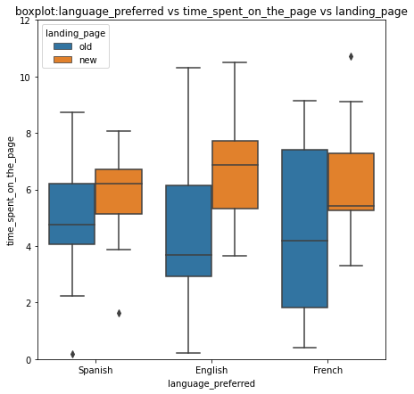

```python
plt.figure(figsize=(7,7)) # figure to be drawn with a width of 7inches and an height of 7inches
plt.title('boxplot:language_preferred vs time_spent_on_the_page vs landing_page') #title of the plot
plt.ylim(0,12) #limit on the y-axis running from 0 to 12
sns.boxplot(data = df, x = 'language_preferred', y='time_spent_on_the_page', hue='landing_page')
plt.show()
```

### Observation

**The median time for individuals who visited the page in spanish for the new landing page was higher than the median time for individuals who visted the old landing page in the three languages.**

**Individuals who visited the old landing page in english had the least median time across board, this might be indicative of the fact that the designs or headlines are not captivating enough on the old landing page to keep the visitors glued to the site and ultimately get converted to a subscriber.**

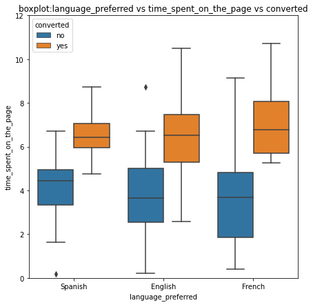

```python
plt.figure(figsize=(7,7)) # figure to be drawn with a width of 7inches and an height of 7inches
plt.title('boxplot:language_preferred vs time_spent_on_the_page vs converted') #title of the plot
plt.ylim(0,12) #limit on the y-axis running from 0 to 12
sns.boxplot(data = df, x = 'language_preferred', y='time_spent_on_the_page', hue='converted')
plt.show()
```

### Observation

**The median time of individuals converted were higher for all three language categories than for those who were not converted**

**The median time for individuals that were not converted is approximately same for viewing the landing pages in english and french**

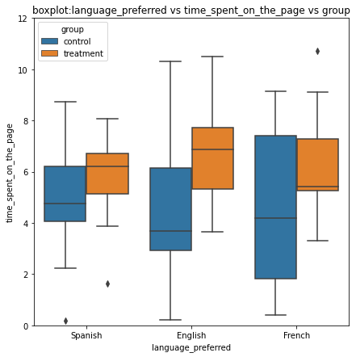

```python
plt.figure(figsize=(7,7)) # figure to be drawn with a width of 7inches and an height of 7inches
plt.title('boxplot:language_preferred vs time_spent_on_the_page vs group') #title of the plot
plt.ylim(0,12) #limit on the y-axis running from 0 to 12
sns.boxplot(data = df, x = 'language_preferred', y='time_spent_on_the_page', hue='group')
plt.show()
```

### Observation

**The median time for the of people in the treatment group that visited the landing page in spanish, english and french is higher than those who visited the site in all three languages for the control group.**

**The median time spent in viewing the site in english for the treatment group is highest compared to the other two languages**

**The median time spent in viewing the site in spanish for the control group is highest compared to the other two languages**

## 1. Do the users spend more time on the new landing page than the existing landing page?

### Perform Visual Analysis

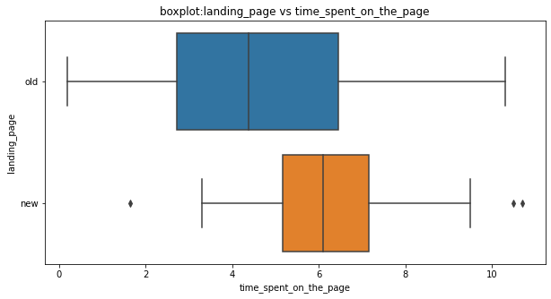

```
sample mean = 5.377800000000002
```

```python
plt.figure(figsize=(10,5)) # figure to be drawn with a width of 10inches and an height of 5inches
plt.title('boxplot:landing_page vs time_spent_on_the_page') #title of the plot
plt.ylim(0,12) #limit on the y-axis running from 0 to 12
sns.boxplot(x = "time_spent_on_the_page", y = "landing_page", data = df);
plt.show()
print('sample mean =', df['time_spent_on_the_page'].mean())
```

### Observation

**1. The distribution of time spent on old landing pages is a little skewed to the right.**

**2. Outliers are observed in the time spent viewing the new landing page meaning some individuals wasted little or no time viewing the page while some took ample time viewing the page**

**3. Individuals spent more time on the new landing page than the old landing page as the median time spent on the new landing page is more than the old landing page**

**4. We don't know the population mean in this case but the estimated mean from the sample is about 5.37 and we need to carry out statistical test to know if more time was spent on the new landing page or the existing landing page**

### Step 1: Define the null and alternate hypotheses

### Let's write the null and alternative hypothesis

Let $\mu_1, \mu_2$ be the mean time spent on the **old_landing_page** and **new_landing_page** respectively.

We will test the null hypothesis

> $H_0:\mu_2 \leq \mu_1$ i.e the average time spent on the new landing page is less than or equal to the old landing page

against the alternate hypothesis

> $H_a:\mu_2>\mu_1$ i.e the average time spent on the new landing page is greater than the time spent on the old landing page.

### Step 2: Select Appropriate test

**This is a case of a one tailed test for the significance of two means.As the population standard deviation or variance is unknown and we are dealing with a random sample of 100 which has been divided into two and subjecting them to two different pages, this is a case of a two-sample independent t-test**

### Step 3: Decide the significance level

**As given in the problem statement, $\alpha=0.05$**

### Step 4: Collect and prepare data

```python
#subsetted data frame for new landing page users
time_spent_new = df[df['landing_page'] == 'new']['time_spent_on_the_page']

#subsetted data frame for old landing page users
time_spent_old = df[df['landing_page'] == 'old']['time_spent_on_the_page'] ##Complete the code
```

```python
print('The mean of the time spent on the new page is: ' + str(round(time_spent_new.mean(),2)))
print('The mean of the time spent on the old page is: ' +str(round(time_spent_old.mean(),2)))
print('The sample standard deviation of the time spent on the new page is:', round(time_spent_new.std(),2))
print('The sample standard deviation of the time spent on the old page is:', round(time_spent_old.std(),2))
```

```
The mean of the time spent on the new page is: 6.22
The mean of the time spent on the old page is: 4.53
The sample standard deviation of the time spent on the new page is: 1.82
The sample standard deviation of the time spent on the old page is: 2.58
```

### Let's test whether the T-test assumptions are satisfied or not

- Continuous data - Yes, the time spent on the landing page is measured on a continuous scale.
- Normally distributed populations - Yes, A random sample of 100 divided int two groups of 50 justifies the central limit statistical theorem of sample size greater than 30 so the data can be assumed to be normally distributed.
- Independent populations - As we are taking random samples and dividing them into two groups and subjecting them to different landing pages,they are said to be independent i.e **A TWO SAMPLE INDEPENDENT T-TEST**
- Unequal population standard deviations - As the sample standard deviations are different, the population standard deviations may be assumed to be different.
- Random sampling from the population - Yes, we are informed that the collected sample was based on simple random sampling.

Therefore, we can use the two sample T-test for this problem.

### Step 5: Calculate the p-value

```python
#import the required functions
from scipy.stats import ttest_ind

# find the p-value
test_stat, p_value = ttest_ind(time_spent_new, time_spent_old, equal_var = False, alternative = 'greater')
print('The p-value is ', p_value)
```

```
The p-value is  0.0001392381225166549
```

### Step 6: Compare the p-value with $\alpha$

```python
# print the conclusion based on p-value
if p_value < 0.05:
    print(f'As the p-value {p_value} is less than the level of significance, we reject the null hypothesis.')
else:
    print(f'As the p-value {p_value} is greater than the level of significance, we fail to reject the null hypothesis.')
```

```
As the p-value 0.0001392381225166549 is less than the level of significance, we reject the null hypothesis.
```

### Step 7: Draw inference

**From the computation above, the p-value is less than 0.05, we reject the null hypothesis.Therefore, there is enough statistical evidence to say that users spend more time on the new landing page than the old landing page.**

## 2. Is the conversion rate (the proportion of users who visit the landing page and get converted) for the new page greater than the conversion rate for the old page?

### Perform Visual Analysis

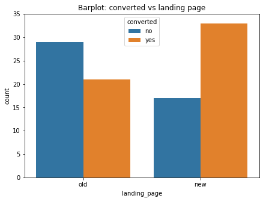

```python
plt.figure(figsize = (7,5))# figure to be drawn with a width of 7inches and an height of 5inches
plt.title('Barplot: converted vs landing page') #title of the plot
sns.countplot(data=df, x="landing_page",hue="converted", )
plt.ylim(0,35) #limit on the y-axis running from 0 to 35
plt.xlabel('landing_page') #x-axis title
plt.show()
```

### Observation

**Most of the users that visited the new landing page were converted while most of the users who visited the old landing page were not converted**

### Step 1: Define the null and alternate hypotheses

### Let's write the null and alternative hypothesis

Let $p_1, p_2$ be the proportion of users who visited the **old_landing_page** and **new_landing_page** respectively.

We will test the null hypothesis

> $H_0:p_2$ $\leq p_1$ i.e i.e the proportion of users who visit the new landing page and get converted is less than or equal to the proportion of users who visit the old landing page and get converted

against the alternate hypothesis

> $H_a: p_2$ $> p_1$ i.e the proportion of users who visit the new landing page and get converted is greater than the proportion of users who visit the old landing page and get converted

### Step 2: Select Appropriate test

**This is a case of a one tailed test for the significance of two proportions from two samples.As the population standard deviation or variance is unknown and we are dealing with a random sample of 100 which has been divided into two and subjecting them to two different pages, this is a case of a two-sample proportions z-test**

### Step 3: Decide the significance level

**As given in the problem statement, $\alpha=0.05$**

### Step 4: Collect and prepare data

```python
# calculate the number of converted users in the new landing page
new_converted_landing_page = df[df['landing_page'] == 'new']['converted'].value_counts()['yes']
# calculate the number of converted users in the old landing page
old_converted_landing_page = df[df['landing_page'] == 'old']['converted'].value_counts()['yes']

print('The numbers of converted users from the new and old landing pages are {0} and {1} respectively'.format(new_converted_landing_page, old_converted_landing_page))

total_new_page = df.landing_page.value_counts()['new'] # total number of users that used the new landing page
total_old_page = df.landing_page.value_counts()['old'] # total number of users that used the old landing page

print('The total numbers of users who served the new and old pages are {0} and {1} respectively'.format(total_new_page, total_old_page ))
```

```
The numbers of converted users from the new and old landing pages are 33 and 21 respectively
The total numbers of users who served the new and old pages are 50 and 50 respectively
```

```python
print(f' The proportions of converted users from the new and old landing pages are {round(33/50,2)}, {round(21/50,2)} respectively')
```

```
 The proportions of converted users from the new and old landing pages are 0.66, 0.42 respectively
```

### Let's test whether the Z-test assumptions are satisfied or not

- Binomially distributed population - YES:people were either converted or not.
- Random sampling from the population - YES:Sample obtained was a simple random simple divided into two groups
- Can the binomial distribution approximated to normal distribution - Yes. For binary data, CLT works slower than usual. The standard thing is to check whether np and n(1-p) are greater than or equal to 10. Here, n and p refer to the sample size and sample proportion respectively.

  > $np_1 = 50\cdot \frac{33}{50} =33 \geq 10\\ n(1-p_1) = 50 \cdot \frac{50-33}{50} =17 \geq 10 \\ np_2 = 50\cdot \frac{21}{50} =21 \geq 10\\ n(1-p_2) = 50 \cdot \frac{50-21}{50} =29 \geq 10 $

### FOR THE CENTRAL LIMIT THEOREM APPROXIMATION TO HOLD

### Step 5: Calculate the p-value

```python
# import the required fuction
from statsmodels.stats.proportion import proportions_ztest

# find the p-value
test_stat, p_value = proportions_ztest([new_converted_landing_page,old_converted_landing_page],[total_new_page,total_old_page],alternative='larger')
print('The p-value is ' + str(p_value))
```

```
The p-value is 0.008026308204056278
```

### Step 6: Compare the p-value with $\alpha$

```python
# print the conclusion based on p-value
if p_value < 0.05:
    print(f'As the p-value {p_value} is less than the level of significance, we reject the null hypothesis.')
else:
    print(f'As the p-value {p_value} is greater than the level of significance, we fail to reject the null hypothesis.')
```

```
As the p-value 0.008026308204056278 is less than the level of significance, we reject the null hypothesis.
```

### Step 7: Draw inference

**From the computation above, the p-value is less than 0.05, we reject the null hypothesis.Therefore, there is enough statistical evidence to say that the conversion rate(the proportion of users who visit the landing page and get converted) for the new page is greater than the conversion rate for the old page.**

## 3. Is the conversion and preferred language are independent or related?

### Perform Visual Analysis

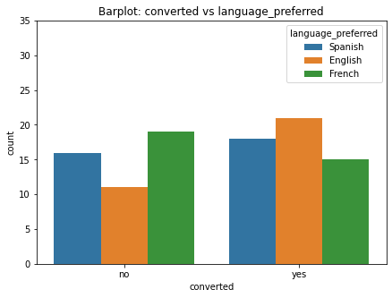

```python
plt.figure(figsize = (7,5))# figure to be drawn with a width of 7inches and an height of 5inches
plt.title('Barplot: converted vs language_preferred') #title of the plot
sns.countplot(data=df, x="converted",hue="language_preferred", )
plt.ylim(0,35) #limit on the y-axis running from 0 to 35
plt.xlabel('converted') #x-axis title
plt.show()
```

### Step 1: Define the null and alternate hypotheses

### Let's write the null and alternative hypothesis

We will test the null hypothesis

> $H_0:$ conversion status is independent of the preferred language.

against the alternate hypothesis

> $H_a:$ conversion status depends on the preferred language.

### Step 2: Select Appropriate test

**This is a case of a determining wether two categorical variables are dependent on one another. In this case the categorical variables are conversion status(YES OR NO) and language preferred (Spanish/French/English). This is a chi-square test of independence.**

### Step 3: Decide the significance level

**As given in the problem statement, $\alpha=0.05$**

### Step 4: Collect and prepare data

```python
contingency_table = pd.crosstab(df['converted'], df['language_preferred'])

contingency_table
```

| language_preferred converted | English | French | Spanish |
| --- | --- | --- | --- |
| no | 11 | 19 | 16 |
| yes | 21 | 15 | 18 |

### Let's test whether the assumptions are satisfied or not

- Categorical variables - Yes
- Expected value of the number of sample observations in each level of the variable is at least 5 - Yes, the number of observations in each level is greater than 5.
- Random sampling from the population - Yes, we are informed that the collected sample is a simple random sample.

### Step 5: Calculate the p-value

```python
from scipy.stats import chi2_contingency

# find the p-value
chi, p_value, dof, expected = chi2_contingency(contingency_table)
print('The p-value is', p_value)
```

```
The p-value is 0.21298887487543447
```

### Step 6: Compare the p-value with $\alpha$

```python
if p_value < 0.05:
    print(f'As the p-value {p_value} is less than the level of significance, we reject the null hypothesis.')
else:
    print(f'As the p-value {p_value} is greater than the level of significance, we fail to reject the null hypothesis.')
```

```
As the p-value 0.21298887487543447 is greater than the level of significance, we fail to reject the null hypothesis.
```

### Step 7: Draw inference

**From the computation above, the p-value is greater than 0.05, we therefore fail to reject the null hypothesis.Therefore, there is not enough statistical evidence to say that the conversion status depends on the language preferred.**

## 4. Is the time spent on the new page same for the different language users?

### Perform Visual Analysis

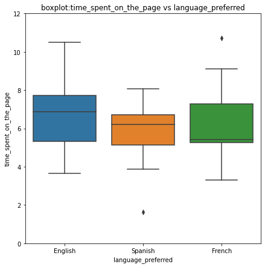

```python
plt.figure(figsize=(7,7)) # figure to be drawn with a width of 7inches and an height of 7inches
plt.title('boxplot:time_spent_on_the_page vs language_preferred') #title of the plot
plt.ylim(0,12) #limit on the y-axis running from 0 to 12
sns.boxplot( x = 'language_preferred', y='time_spent_on_the_page',data = df[df['landing_page'] == 'new'])
plt.show()
```

### Observation

**The median time spent on the landing page by users who visited the page in frnch language is the least compared to the other languages but this is not enough statistical evidence to conclude that time spent on the new landing site is dependent on the language used and statistical analysis needs to be carried out**

### Step 1: Define the null and alternate hypotheses

### Let's write the null and alternative hypothesis

Let $\mu_1, \mu_2, \mu_3$ be the means of time spent on the new page for language type English, French and Spanish respectively.

We will test the null hypothesis

> $H_0: \mu_1 = \mu_2 = \mu_3$

against the alternative hypothesis

> $H_a: $ At least mean time spent on the new page for one of the language preferred is different from the rest..

### Taking a look at the sample data

```python
df.head()
```

|  | user_id | group | landing_page | time_spent_on_the_page | converted | language_preferred |
| --- | --- | --- | --- | --- | --- | --- |
| 0 | 546592 | control | old | 3.48 | no | Spanish |
| 1 | 546468 | treatment | new | 7.13 | yes | English |
| 2 | 546462 | treatment | new | 4.40 | no | Spanish |
| 3 | 546567 | control | old | 3.02 | no | French |
| 4 | 546459 | treatment | new | 4.75 | yes | Spanish |

```python
# To get the distribution of people who viewed the new page in the different languages
df[df['landing_page'] == 'new']['language_preferred'].value_counts()
```

```
Spanish    17
French     17
English    16
Name: language_preferred, dtype: int64
```

```
language_preferred
English    6.663750
French     6.196471
Spanish    5.835294
Name: time_spent_on_the_page, dtype: float64
```

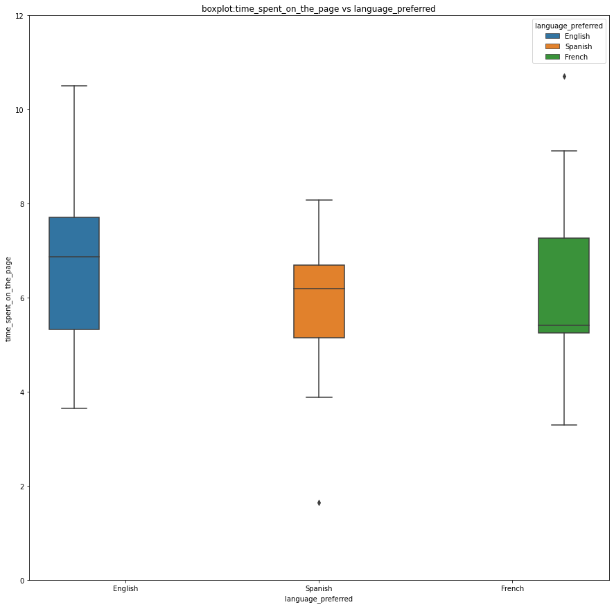

```python
print(df[df['landing_page'] == 'new'].groupby("language_preferred")["time_spent_on_the_page"].mean())
plt.figure(figsize=(15,15)) # figure to be drawn with a width of 15inches and an height of 15inches
plt.title('boxplot:time_spent_on_the_page vs language_preferred') #title of the plot
plt.ylim(0,12) #limit on the y-axis running from 0 to 12
sns.boxplot( x = 'language_preferred', y='time_spent_on_the_page',data = df[df['landing_page'] == 'new'], hue='language_preferred')
plt.show()
```

### Step 2: Select Appropriate test

This problem involves three population means and a 1-way ANOVA test would be used here provided normality and equality of variance assumptions are verified.

Now, the normality and equality of variance assumptions need to be checked.

- For testing of normality, Shapiro-Wilk’s test is applied to the response variable.
- For equality of variance, Levene test is applied to the response variable.

### Shapiro-Wilk’s test

We will test the null hypothesis

> $H_0:$ time spent on the new page follows a normal distribution against

against the alternative hypothesis

> $H_a:$ time spent on the new page does not follow a normal distribution

```python
# Assumption 1: Normality
from scipy import stats
w, p_value = stats.shapiro(df[df['landing_page'] == 'new']['time_spent_on_the_page'])

# find the p-value
print('The p-value is', p_value)
```

```
The p-value is 0.8040016293525696
```

**since the P-value is greater tha 0.05 significance level, we fail to reject the null hypothesis and therefore the time spent on page follows a normal distribution**

### Levene’s test

We will test the null hypothesis

> $H_0$: All the population variances are equal

against the alternative hypothesis

> $H_a$: At least one variance is different from the rest

```python
#Assumption 2: Homogeneity of Variance
from scipy.stats import levene

statistic, p_value = stats.levene(
    df[(df['landing_page'] == 'new') & (df['language_preferred'] == 'English')]['time_spent_on_the_page'],
    df[(df['landing_page'] == 'new') & (df['language_preferred'] == 'French')]['time_spent_on_the_page'],
    df[(df['landing_page'] == 'new') & (df['language_preferred'] == 'Spanish')]['time_spent_on_the_page'])
# find the p-value
print('The p-value is', p_value)
```

```
The p-value is 0.46711357711340173
```

**Since the p-value is large, we fail to reject the null hypothesis of homogeneity of variances.**

### Let's test whether the assumptions are satisfied or not

- The populations are normally distributed - Yes, the normality assumption is verified using the Shapiro-Wilk’s test.
- Samples are independent simple random samples - Yes, we are informed that the collected sample is a simple random sample.
- Population variances are equal - Yes, the homogeneity of variance assumption is verified using the Levene's test.

### Step 3: Decide the significance level

**As given in the problem statement, $\alpha=0.05$**

### Step 4: Collect and prepare data

```python
# separate the time spent on the new page with respect to the three languages preferred
time_spent_English = df[(df['landing_page'] == 'new') & (df['language_preferred'] == 'English')]['time_spent_on_the_page']
time_spent_French = df[(df['landing_page'] == 'new') & (df['language_preferred'] == 'French')]['time_spent_on_the_page']
time_spent_Spanish = df[(df['landing_page'] == 'new') & (df['language_preferred'] == 'Spanish')]['time_spent_on_the_page']
```

### Step 5: Calculate the p-value

```python
# perform one-way anova test using the f_oneway function from scipy.stats library
test_stat, p_value = stats.f_oneway(time_spent_English, time_spent_French, time_spent_Spanish)

print('The p-value is ', p_value)
```

```
The p-value is  0.43204138694325955
```

### Step 6: Compare the p-value with $\alpha$

```python
if p_value < 0.05:
    print(f'As the p-value {p_value} is less than the level of significance, we reject the null hypothesis.')
else:
    print(f'As the p-value {p_value} is greater than the level of significance, we fail to reject the null hypothesis.')
```

```
As the p-value 0.43204138694325955 is greater than the level of significance, we fail to reject the null hypothesis.
```

### SUMMARY:

#### 1. Do the users spend more time on the new landing page than the existing landing page?

*Therefore, there is enough statistical evidence to say that users spend more time on the new landing page than the old landing page.*

#### 2. Is the conversion rate (the proportion of users who visit the landing page and get converted) for the new page greater than the conversion rate for the old page?

*There is enough statistical evidence to say that the conversion rate(the proportion of users who visit the landing page and get converted) for the new page is greater than the conversion rate for the old page.*

#### 3. Is the conversion and preferred language are independent or related?

*There is not enough statistical evidence to say that the conversion status depends on the language preferred.*

## Conclusion

**Based on the analysis done above, French and spanish are the two preferred language of choice.**

**More people got converted to subscribers when they viewed the landing pages.**

**Users spent more time on the new landing page than the old landing page as can be seen from the mean and median times spent on the new and old landing pages respectively.**

**The conversion rate on the new landing page is higher when compared to the old landing page**

**Converted users spent more time on the new landing page than the old landing page as language could not play a role in deciding how long a person stays on either pages.**

## Business Recommendations

**Based on the summary above, the company can make use of the new landing page as it has been statistically proven that new subscribers tend to be added upon viewing the new landing page**

**Languages seems not to be a deciding factor in expanding their business as it has been statistically seen**